# Solutions for exercises of Section 8.

### Finding a suitable model using auto.arima and trying other models

```r
fit = auto.arima(mcopper, lambda = lambda)
fit
```

```
Series: mcopper
ARIMA(0,1,1)
Box Cox transformation: lambda= 0.1919047

Coefficients:
         ma1
      0.3720
s.e.  0.0388

sigma^2 = 0.04997:  log likelihood = 45.05
AIC=-86.1   AICc=-86.08   BIC=-77.43
```

Other models which can be tried are ARIMA(2,1,0) and ARIMA(7,1,0):

```r
fit1 = Arima(mcopper, c(2,1,0), lambda = lambda)
fit2 = Arima(mcopper, c(7,1,0), lambda = lambda)
```

```r
c(fit$aicc, fit1$aicc, fit2$aicc)
```

```
[1] -86.07547 -82.51186 -80.07452
```

The lowest AICc is for model ARIMA(0,1,1) ( the model which was proposed by auto.arima).

### Residuals diagnostics for model ARIMA(0,1,1)

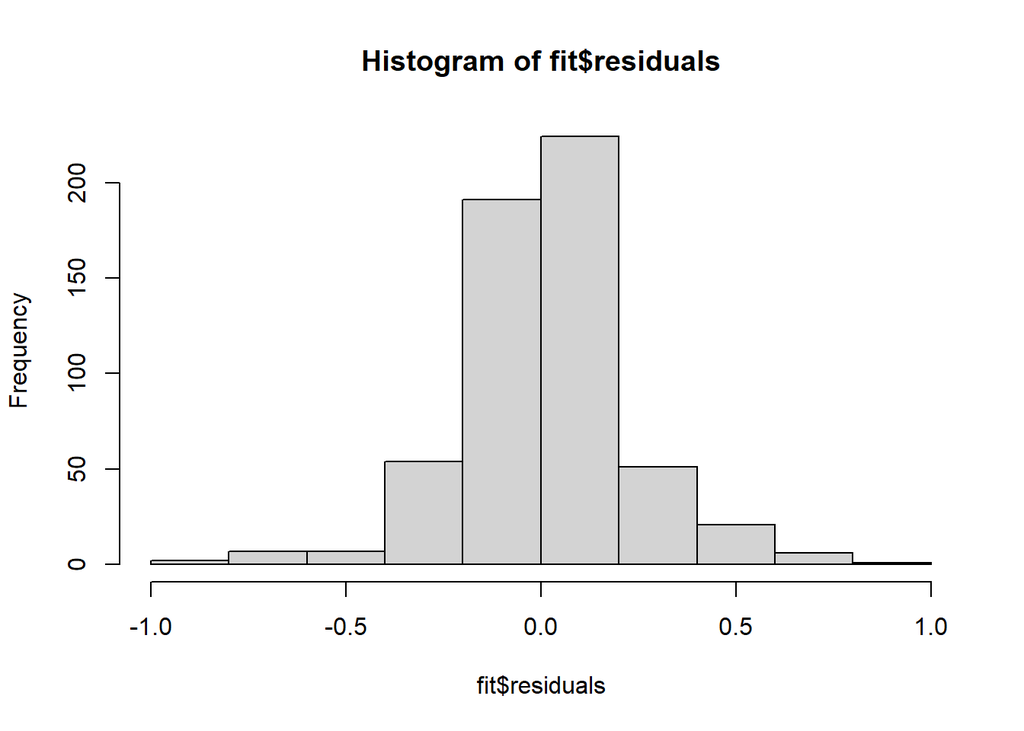

```r
hist(fit$residuals)
```

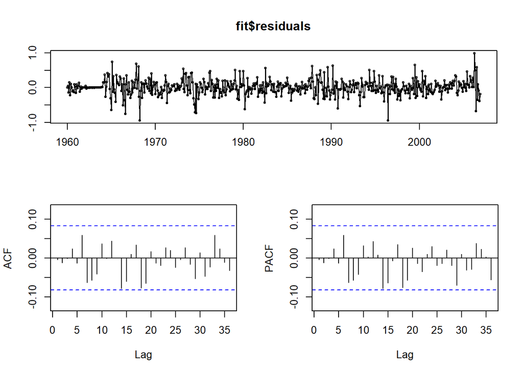

```r
tsdisplay(fit$residuals)
```

```r
Box.test(fit$residuals, lag = 12, type = "Ljung-Box", fitdf = 1)
```

```
    Box-Ljung test

data:  fit$residuals
X-squared = 9.4832, df = 11, p-value = 0.5774
```

- The residuals look normal at the histogram
- No obvious patterns are visible on the graph of the residuals
- The residuals are white noise

### Comparing forecasts of auto.arima and ets

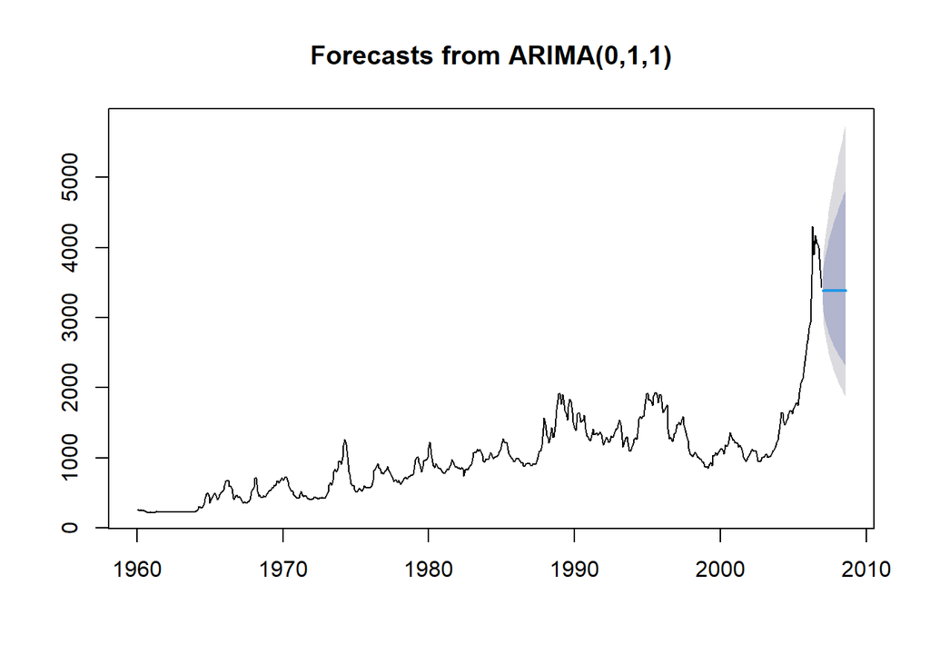

```r
fcast = forecast(fit, h = 20)
plot(fcast)
```

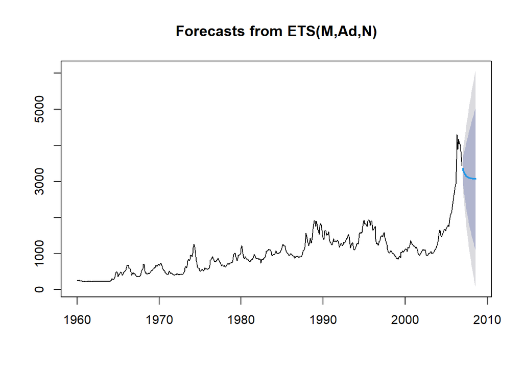

```r
fit.ets = ets(mcopper)
fcast.ets = forecast(fit.ets, h = 20)
plot(fcast.ets)
```

Forecasts look differently, but taking into account that the forecasting intervals are very wide, both forecasts provide similar results.

## Exercise 8.10

### Data set condmilk

```r
condmilk
```

```
        Jan    Feb    Mar    Apr    May    Jun    Jul    Aug    Sep    Oct
1971  81.28  69.39  67.63  51.25 103.97 133.83 162.37 172.91 163.01 151.50
1972  74.29  63.98  61.18  76.48 107.98 124.97 145.57 140.20 143.84 138.80
1973  60.18  55.16  35.62  56.18  85.44 114.08 133.64  67.14  95.58  89.37
1974  54.49  57.50  62.16  76.67 110.04 127.38 156.47 167.56 153.54 124.08
1975  68.13  61.77  54.31  60.30  84.18 104.05 114.66 105.55  96.61  70.94
1976  44.53  49.58  57.39  76.76 104.57 125.41 143.11 136.35 135.15 131.70
1977  66.29  63.49  62.97  66.43 101.49 127.69 133.21 158.72 148.61 134.31
1978  59.74  52.87  52.07  57.38  79.43 101.40 120.19 134.38 135.97 113.83
1979  65.96  56.36  49.57  68.33  90.32 117.06 134.69 131.67 129.25 118.77
1980  75.28  73.89  76.24  88.58 105.83 115.84 127.76 131.75 119.63  93.38
        Nov    Dec
1971 111.73  88.58
1972 104.06  74.70
1973  75.24  69.18
1974 100.97  79.17
1975  63.91  58.61
1976  96.87  70.63
1977 100.99  75.16
1978  84.38  70.28
1979  88.44  76.79
1980  75.55  51.79
```

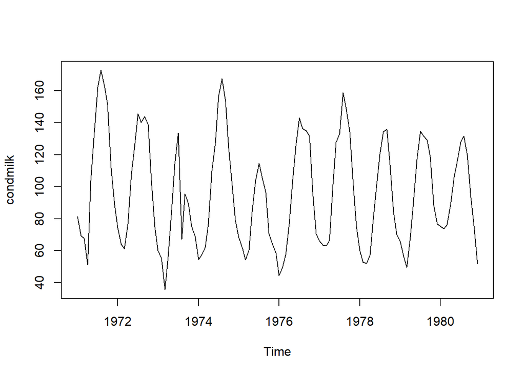

```r
plot(condmilk)
```

The trend in the data very flat, therefore transformation will not adjust sizes of the seasonal patterns much. No transformation is required.

The data is not stationary due to the seasonal pattern. Differencing with lag 12 is required:

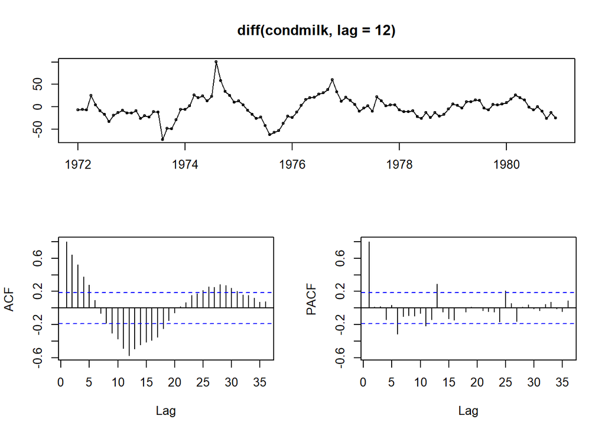

```r
tsdisplay(diff(condmilk, lag = 12))
```

There is still a lot of autocorrelation left in the data. ACF and PACF graphs suggest one more differencing.

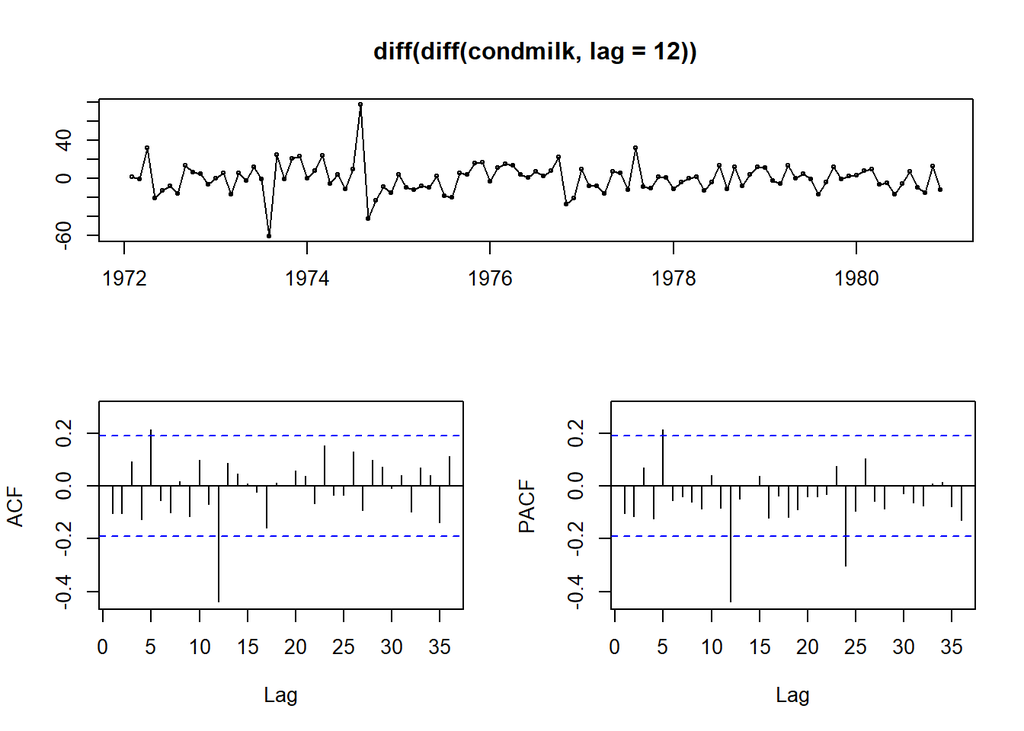

```r
tsdisplay(diff(diff(condmilk, lag = 12)))
```

After two differencing the data is stationary. The suggested models are:

ARIMA(0,1,0)(0,1,1) ARIMA(0,1,0)(2,1,0) ARIMA(5,1,0)(0,1,1) ARIMA(5,1,0)(2,1,0) ARIMA(0,1,5)(0,1,1) ARIMA(0,1,5)(2,1,0)

```r
fit1 = Arima(condmilk, c(0,1,0), c(0,1,1))
fit2 = Arima(condmilk, c(0,1,0), c(2,1,0))
fit3 = Arima(condmilk, c(5,1,0), c(0,1,1))
fit4 = Arima(condmilk, c(5,1,0), c(2,1,0))
fit5 = Arima(condmilk, c(0,1,5), c(0,1,1))
fit6 = Arima(condmilk, c(0,1,5), c(2,1,0))
```

```r
c(fit1$aicc, fit2$aicc, fit3$aicc,  fit4$aicc, fit5$aicc, fit6$aicc)
```

```
[1] 852.2575 856.2046 855.7674 861.1634 856.4325 861.4841
```

The best model is ARIMA(0,1,0)(0,1,1).

### Residuals analysis

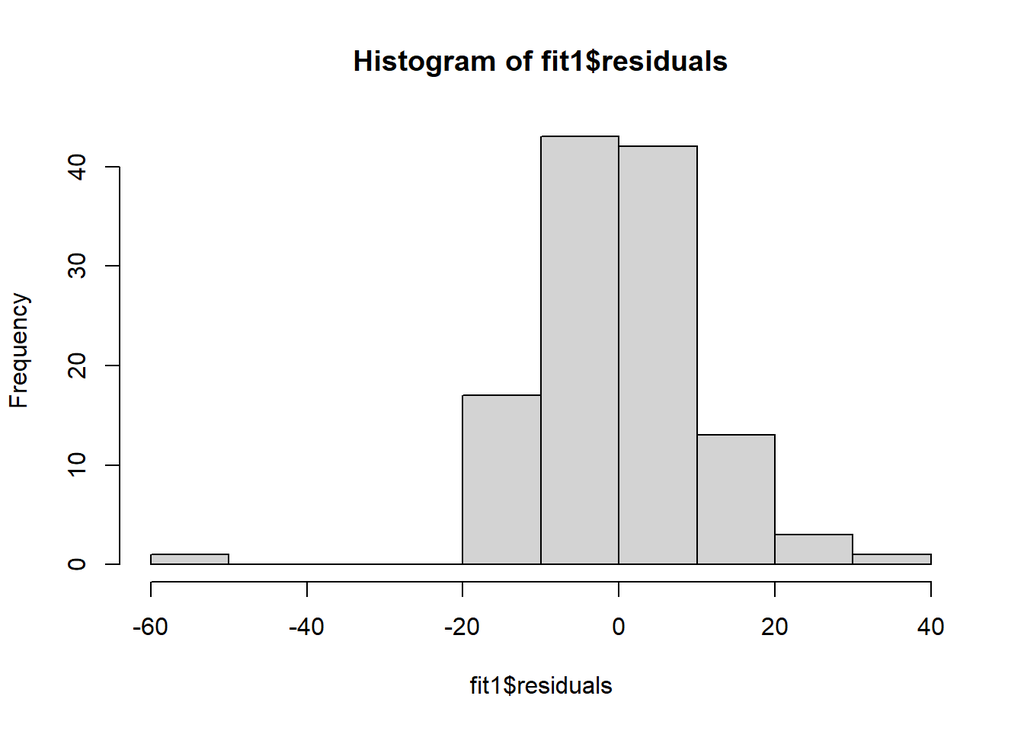

```r
hist(fit1$residuals)
```

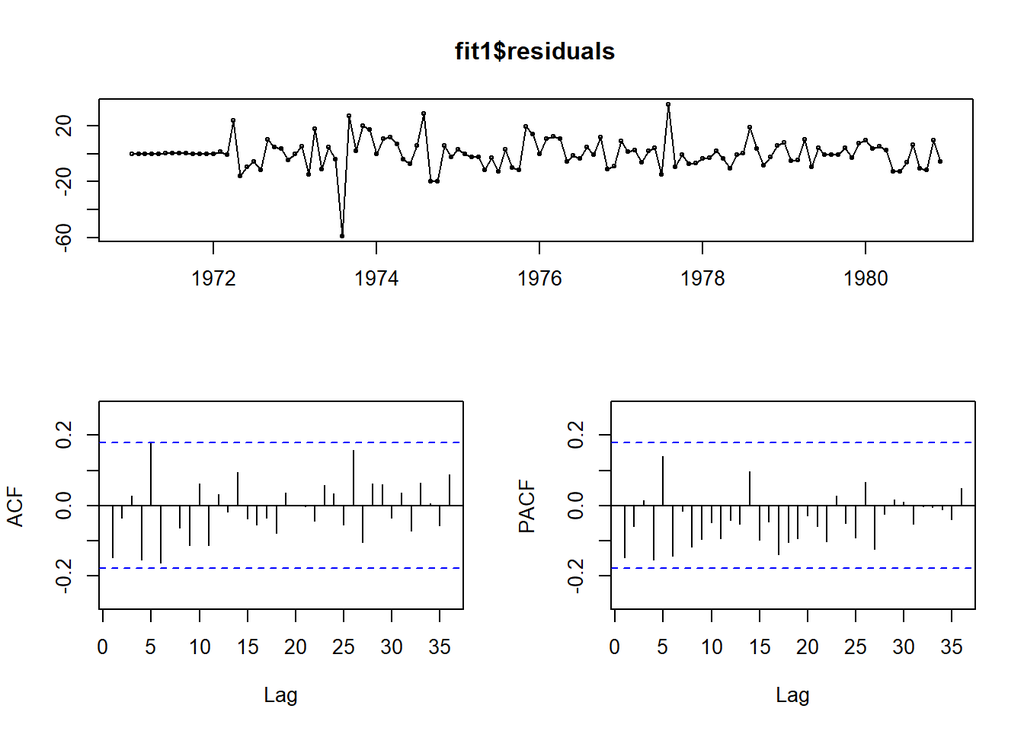

```r
tsdisplay(fit1$residuals)
```

```r
Box.test(fit1$residuals, lag = 24, type = "Ljung-Box", fitdf = 1)
```

```
    Box-Ljung test

data:  fit1$residuals
X-squared = 22.189, df = 23, p-value = 0.5089
```

Residuals’ distribution is close to normal. Residuals are uncorrelated. The model is satisfactory.

### Forecasting 24 months ahead and comparing with ets forecasts

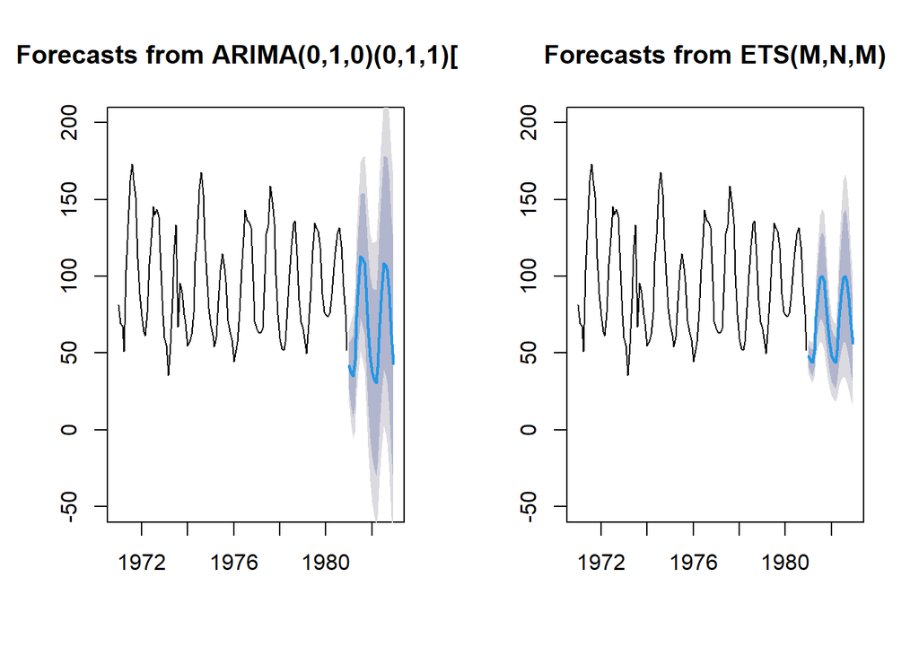

```r
fcast1 = forecast(fit1, h = 24)
fit.ets = ets(condmilk)
fcast.ets = forecast(fit.ets, h = 24)
par(mfrow=c(1,2))
plot(fcast1, ylim = c(-50,200))
plot(fcast.ets, ylim = c(-50,200))
```

The point forecasts are similar, although the forecasting intervals are smaller for ets.

## Exercise 8.11

### Forecasting with non-seasonal model applied to the seasonally adjusted data obtained from STL

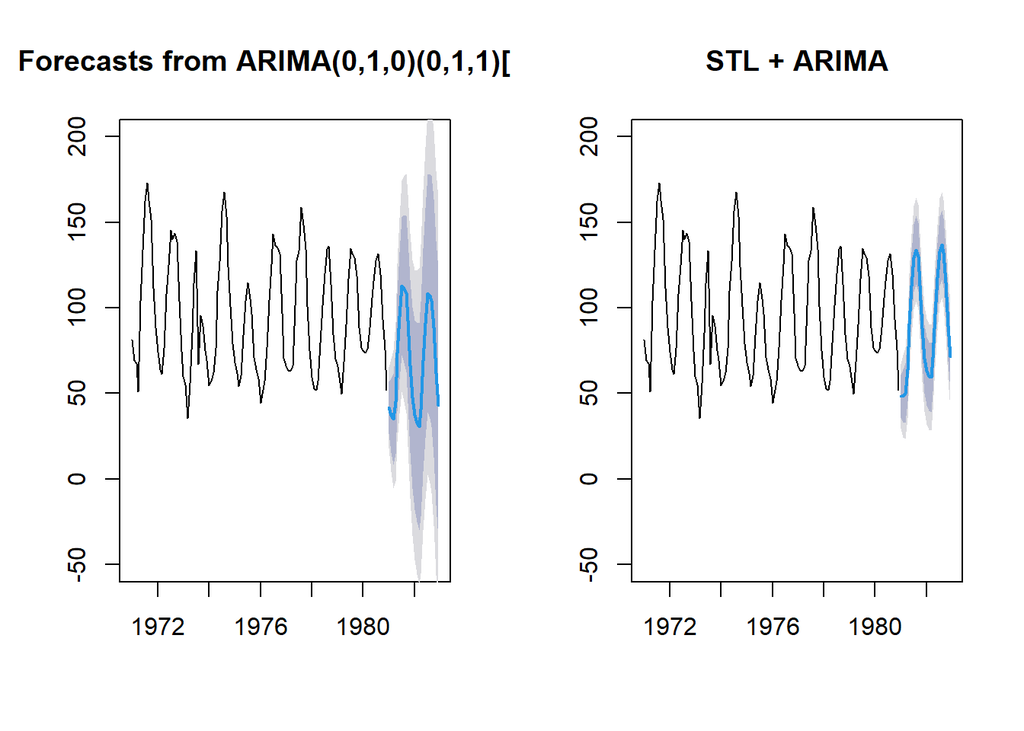

```r
fcast.stlf = stlf(condmilk, h = 24, method = "arima")
par(mfrow=c(1,2))
plot(fcast1, ylim = c(-50,200))
plot(fcast.stlf, ylim = c(-50,200), main = "STL + ARIMA")
```

Forecasting with stlf looks very promising due to very small forecasting intervals. Although the forecasting intervals for stlf are probably smaller than they should be. It is because the uncertainty in seasonal decomposition is not taken into account during forecasting intervals’ calculations.